# Lab 14

Eric Goolsby

11/23/2021

First let’s load the following R packages:

```r
library(tidyverse)
library(easystats)
```

## Linear Regression and p-values

When you fit a linear regression on two variables (`X` and `Y`), you are assessing whether the two variables are correlated. We can simulate correlated data using the `rnorm` function. In the code chunk below, I’ve simulated a correlated dataset: the simulated slope is 3, and the simulated y-intercept is -5.

```r
x <- rnorm(n = 100,mean = 0,sd = 1)
y <- 3*x - 5 + rnorm(n = 100,mean = 0,sd = 1)
dat1 <- data.frame(x = x,y = y)

mod1 <- lm(y~x,data = dat1)
```

We can visualize the relationship using the `easystats` package `see`:

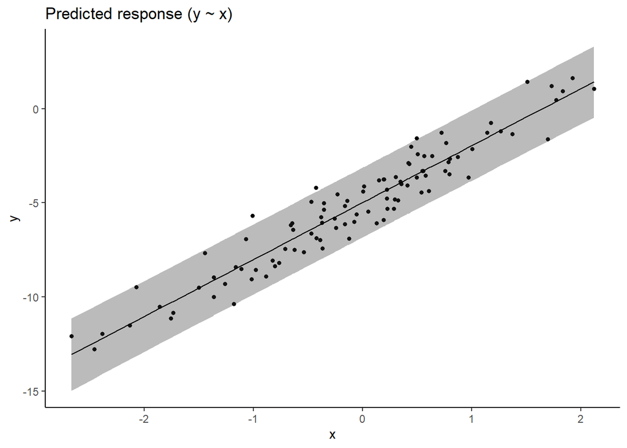

```r
mod1 %>%
  estimate_prediction() %>%
  plot() +
  theme_classic()
```

We can also check out the regression coefficients (intercept and slope), as well as the summary statistics like R-squared and the p-value for the regression:

```r
coef(mod1)
```

```
## (Intercept)           x
##   -4.983567    3.025623
```

```r
summary(mod1)
```

```
##
## Call:
## lm(formula = y ~ x, data = dat1)
##
## Residuals:
##      Min       1Q   Median       3Q      Max
## -1.81466 -0.62724 -0.07051  0.68794  2.35558
##
## Coefficients:
##             Estimate Std. Error t value Pr(>|t|)
## (Intercept) -4.98357    0.09325  -53.45   <2e-16 ***
## x            3.02562    0.09228   32.79   <2e-16 ***
## ---
## Signif. codes:  0 '***' 0.001 '**' 0.01 '*' 0.05 '.' 0.1 ' ' 1
##
## Residual standard error: 0.9292 on 98 degrees of freedom
## Multiple R-squared:  0.9165, Adjusted R-squared:  0.9156
## F-statistic:  1075 on 1 and 98 DF,  p-value: < 2.2e-16
```

The R-squared values is a measure of variance explained. An R-squared of zero means there’s no correlation whatsoever, whereas an R-squared of 1 indiciates a 100% perfect fit. To access the R-squared value for our model:

```r
summary(mod1)$r.squared
```

```
## [1] 0.9164619
```

A p-value is a hypothesis test. Normally, if `p < 0.05`, then the null hypothesis is rejected and we generally say it’s a ‘significant’ result (for better or worse). So a linear regression with a `p < 0.05` might be described as a significant correlation between `x` and `y`.

Getting the p-value is slightly trickier. In the output of `summary(mod1)` there are three p-values: 1) one for the intercept under the column `Pr(>|t|)`, 2) another for the `x` slope right underneath the intercept p-value, and finally 3) the p-value for the overall regression (bottom right of the output of `summary(mod1)`). You’ll notice the second and third p-values are the same. That’s true if you only have one predictor (as we do here), but they’re different if you have multiple predictors (i.e. multiple regression).

The overall regression p-value is computed internally using an F-test:

```r
f <- summary(mod1)$fstatistic
p <- pf(f[1],f[2],f[3],lower.tail=F)
```

But since we only have one predictor, we can just retrieve the p-value for the slope. The following function (from the `parameters` package within `easystats`) gives you the intercept and slope p-values (in order), so we want the second p-value.

```r
parameters(mod1)$p
```

```
## [1] 2.690686e-74 1.247713e-54
```

```r
parameters(mod1)$p[2]
```

```
## [1] 1.247713e-54
```

Note: you could also extract it from the table in `summary(mod1)$coefficients`, which is faster than the `parameters` function, but slightly trickier:

```r
summary(mod1)$coefficients
```

```
##              Estimate Std. Error   t value     Pr(>|t|)
## (Intercept) -4.983567 0.09324699 -53.44480 2.690686e-74
## x            3.025623 0.09227559  32.78898 1.247713e-54
```

```r
summary(mod1)$coefficients[2,4]
```

```
## [1] 1.247713e-54
```

Now let’s simulate some non-correlated data. In other words, `x` and `y` will be indepednent:

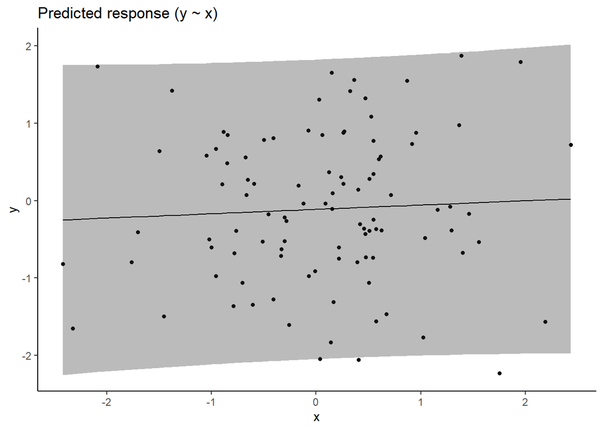

```r
x <- rnorm(n = 100,mean = 0,sd = 1)
y <- rnorm(n = 100,mean = 0,sd = 1)
dat2 <- data.frame(x = x,y = y)

mod2 <- lm(y~x,data = dat2)
mod2 %>%
  estimate_prediction() %>%
  plot() +
  theme_classic()
```

In this example, we basically have a flat line (and very wide confidence intervals). The R-squared value is very low, and the p-value is probably greater than 0.05:

```r
summary(mod2)
```

```
##
## Call:
## lm(formula = y ~ x, data = dat2)
##
## Residuals:
##     Min      1Q  Median      3Q     Max
## -2.2182 -0.5981 -0.0781  0.7670  1.9676
##
## Coefficients:
##             Estimate Std. Error t value Pr(>|t|)
## (Intercept) -0.11299    0.09727  -1.162    0.248
## x            0.05606    0.10464   0.536    0.593
##
## Residual standard error: 0.971 on 98 degrees of freedom
## Multiple R-squared:  0.00292,    Adjusted R-squared:  -0.007254
## F-statistic: 0.287 on 1 and 98 DF,  p-value: 0.5934
```

Interestingly, if you run the regerssion multiple times, you’ll notice tha you get a ‘significant’ correlation about 5% of the time. When this happens, it’s called a false positive. Try running the following code over and over again until you see a false positive (a p-value that is less than 0.05). Count how many times you have to click the green button before to get a significant p-value:

```r
x <- rnorm(n = 100,mean = 0,sd = 1)
y <- rnorm(n = 100,mean = 0,sd = 1)
dat3 <- data.frame(x = x,y = y)

mod3 <- lm(y~x,data = dat3)
summary(mod3)$coefficients[2,4]
```

```
## [1] 0.514324
```

## for loops

The manual re-running is effective, but tedious. We can avoid repetitive coding with loops. A loop simply allows you to repeat code automatically, as follows:

```r
for(i in 1:15)
{
  cat("The current value of i is",i,"\n")
}
```

```
## The current value of i is 1
## The current value of i is 2
## The current value of i is 3
## The current value of i is 4
## The current value of i is 5
## The current value of i is 6
## The current value of i is 7
## The current value of i is 8
## The current value of i is 9
## The current value of i is 10
## The current value of i is 11
## The current value of i is 12
## The current value of i is 13
## The current value of i is 14
## The current value of i is 15
```

We can loop over any values we want:

```r
values <- c(2,4,6,8,100)

for(i in values)
{
  cat("The current value of i is",i,"\n")
}
```

```
## The current value of i is 2
## The current value of i is 4
## The current value of i is 6
## The current value of i is 8
## The current value of i is 100
```

And we can even create nested loops. Examine the following output:

```r
for(i in 1:5)
{
  for(j in 1:3)
  {
    cat("The current value of i is",i,"and the current value of j is",j,"\n")
  }
}
```

```
## The current value of i is 1 and the current value of j is 1
## The current value of i is 1 and the current value of j is 2
## The current value of i is 1 and the current value of j is 3
## The current value of i is 2 and the current value of j is 1
## The current value of i is 2 and the current value of j is 2
## The current value of i is 2 and the current value of j is 3
## The current value of i is 3 and the current value of j is 1
## The current value of i is 3 and the current value of j is 2
## The current value of i is 3 and the current value of j is 3
## The current value of i is 4 and the current value of j is 1
## The current value of i is 4 and the current value of j is 2
## The current value of i is 4 and the current value of j is 3
## The current value of i is 5 and the current value of j is 1
## The current value of i is 5 and the current value of j is 2
## The current value of i is 5 and the current value of j is 3
```

OK, getting back to linear regression and false positives. Let’s run our regression 1000 times, and store the regression p-values in a vector. Then we can check and see how often we get a false positive:

```r
p_values <- numeric(length = 1000)

for(i in 1:1000)
{
  x <- rnorm(n = 100,mean = 0,sd = 1)
  y <- rnorm(n = 100,mean = 0,sd = 1)
  dat3 <- data.frame(x = x,y = y)

  mod3 <- lm(y~x,data = dat3)
  p_values[i] <- summary(mod3)$coefficients[2,4]

}
```

Notice in the above code chunk, we stored the p-value in position `[i]` of the vector. That’s one of the useful ways we can use for loops to our advantage. Let’s see how often we got a false positive (how many out of 1000 runs). We use `p_values < 0.05` to create a logical vector. We can count the number of `TRUE` values by using `sum(p_values)`, because `TRUE` has a value of `1` and `FALSE` has a value of `0`. We can multiply the fraction by `100` to convert it to a percentage:

```r
sum(p_values < 0.05) / length(p_values) * 100
```

```
## [1] 4.4
```

## Assumptions of linear regression

When we run linear regression, we are assuming that our data are independnet and identically distributed (i.i.d.). (Technically, we’re assuming the residuals (`y - (m*x + b)`) are i.i.d.). Let’s see what happens when we violate the assumption of independence.

We’re going to simulate `x` and `y` in three steps. First, let’s simulate two (uncorrelated) data points for `x` and `y`. Let’s call these `part_one`.

```r
x_part_one <- rnorm(n = 2,mean = 0,sd = 10)
y_part_one <- rnorm(n = 2,mean = 0,sd = 10)
```

```r
x_part_two <- rnorm(n = 25,mean = x_part_one[1],sd = 0.1)
x_part_three <- rnorm(n = 25,mean = x_part_two[2],sd = 0.1)

y_part_two <- rnorm(n = 25,mean = y_part_one[1],sd = 0.1)
y_part_three <- rnorm(n = 25,mean = y_part_two[2],sd = 0.1)
```

Let’s discard `part_one`, and put the rest together, and plot the result:

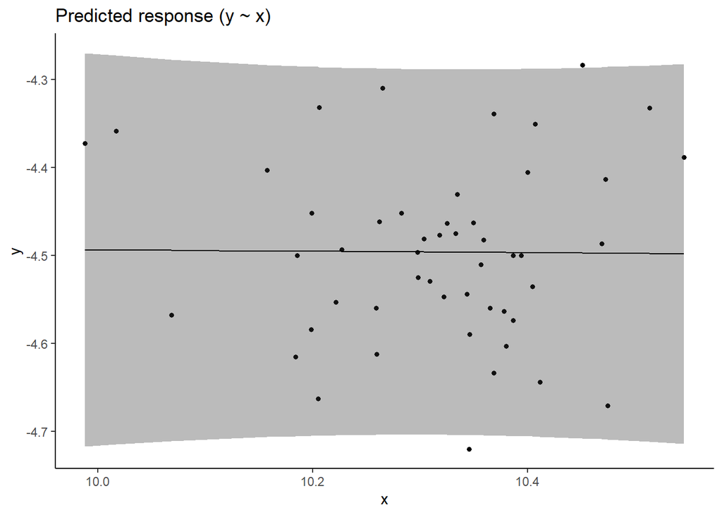

```r
x <- c(x_part_two,x_part_three)
y <- c(y_part_two,y_part_three)
dat4 <- data.frame(x = x,y = y)

mod4 <- lm(y~x, data = dat4)
mod4 %>%
  estimate_prediction() %>%
  plot() +
  theme_classic()
```

```r
p_values <- numeric(length = 1000)

for(i in 1:1000)
{
  x_part_one <- rnorm(n = 2,mean = 0,sd = 10)
  y_part_one <- rnorm(n = 2,mean = 0,sd = 10)
  x_part_two <- rnorm(n = 25,mean = x_part_one[1],sd = 0.1)
  x_part_three <- rnorm(n = 25,mean = x_part_two[2],sd = 0.1)

  y_part_two <- rnorm(n = 25,mean = y_part_one[1],sd = 0.1)
  y_part_three <- rnorm(n = 25,mean = y_part_two[2],sd = 0.1)

  x <- c(x_part_two,x_part_three)
  y <- c(y_part_two,y_part_three)
  dat4 <- data.frame(x = x,y = y)

  mod4 <- lm(y~x, data = dat4)
  p_values[i] <- summary(mod4)$coefficients[2,4]
}

sum(p_values < 0.05) / length(p_values)
```

```
## [1] 0.175
```

The false positive rate is now almost 20%! You might be wondering, why is this relevant? When would this ever happen in the real world?

Suppose it’s 1 million years ago, and the common ancestor of a frog species just underwent a speciation event. In other words, there are two frog species (with the same common ancestor). Imagine we’re interested in the following traits: frog tongue length (`x`), and how high they can hop (`y`).

Now, fast-forward 900,000 years. The species are evolving in different ecological niches, and the tonguge length and hop height for the two species is gradually evolving to different values.

Now, imagine that the first frog species colonizes 25 islands, and the second frog species colonizes 25 *different* islands. In other words: *instant speciation event*. Two species are now 50 species.

Let the 50 frog species evolve on their islands for 100,000 years. Now finally, at present day, let’s measure each species tongue length and hop heights. Suppose we observe a significant correlation. Can we safely assume that these two traits are correlated?

It might be tempting to say “of course!”. However, as we saw with our simulations, when you violate the assumption of independence (as is the case when you have evolutionarily related species), then your risk of seeing a false positive correlation increases.

This leads us to the work of Felsenstein 1985: *Phylogenies and the Comparative Method*. We can use some R package to simulate this. Install the following R packages if you don’t have them already, and then load them:

```r
# install.packages("ape")
# install.packages("phylolm")
# install.packages("phytools")

library(ape)
library(phylolm)
library(phytools)
```

We can build a phylogenetic tree that matches our 50 frog species. Don’t worry about the code, just run it:

```r
treeA <- starTree(species = paste("frog_A_",1:25,sep=""),branch.lengths = rep(.1,25))
treeB <- starTree(species = paste("frog_B_",26:50,sep=""),branch.lengths = rep(.1,25))
treeA$root.edge <- 0.9
treeB$root.edge <- 0.9
tree <- bind.tree(treeA,treeB,where = "root",position = 0.9)
```

Now let’s plot our frog phylogeny:

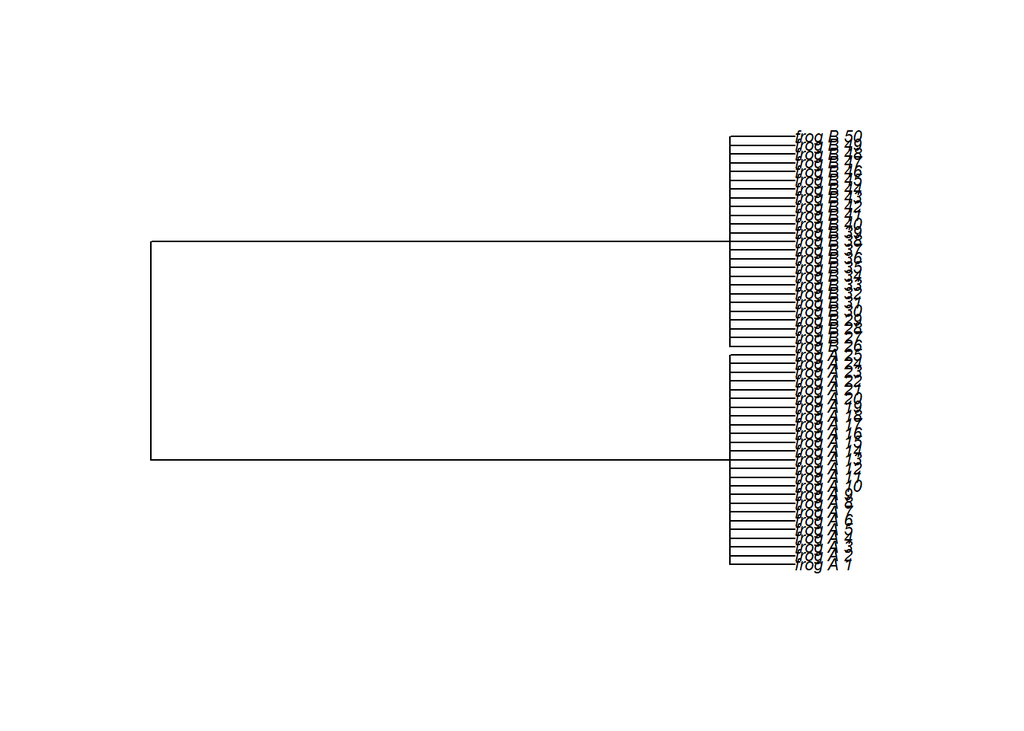

```r
plot(tree,cex = 0.7)
```

Now let’s simulate some trait evolution on the tree (I’ve added 10 to both of them so they are positive values)

```r
tongue_length <- rTrait(n = 1,phy = tree) + 10
hop_height <- rTrait(n = 1,phy = tree) + 10

tongue_length
```

```
##  frog_A_1  frog_A_2  frog_A_3  frog_A_4  frog_A_5  frog_A_6  frog_A_7  frog_A_8
##  9.039590  9.168998  8.432111  8.851733  8.867555  8.883944  8.515446  8.835172
##  frog_A_9 frog_A_10 frog_A_11 frog_A_12 frog_A_13 frog_A_14 frog_A_15 frog_A_16
##  8.453481  9.052411  8.501771  8.682696  8.854358  8.662725  8.609916  8.447893
## frog_A_17 frog_A_18 frog_A_19 frog_A_20 frog_A_21 frog_A_22 frog_A_23 frog_A_24
##  8.602817  9.011786  8.538861  8.981681  8.589578  8.835727  8.430999  8.977347
## frog_A_25 frog_B_26 frog_B_27 frog_B_28 frog_B_29 frog_B_30 frog_B_31 frog_B_32
##  8.323276 11.042107 10.956772 11.049308 10.622042 11.053547 10.295855 10.799538
## frog_B_33 frog_B_34 frog_B_35 frog_B_36 frog_B_37 frog_B_38 frog_B_39 frog_B_40
## 10.493566 10.460074 10.810273 10.484936 10.639153 10.293403 11.010800 10.879831
## frog_B_41 frog_B_42 frog_B_43 frog_B_44 frog_B_45 frog_B_46 frog_B_47 frog_B_48
## 11.146004 10.541433 10.469950 10.538200 10.756622 10.708034 11.236078 10.512667
## frog_B_49 frog_B_50
## 11.137768 10.760446
```

```r
hop_height
```

```
##  frog_A_1  frog_A_2  frog_A_3  frog_A_4  frog_A_5  frog_A_6  frog_A_7  frog_A_8
## 10.483053  9.599335 10.071979 10.464821  9.515111  9.774596  9.459050 10.257285
##  frog_A_9 frog_A_10 frog_A_11 frog_A_12 frog_A_13 frog_A_14 frog_A_15 frog_A_16
## 10.023205  9.930666 10.111397  9.599047  9.665723  9.623358  9.997739  9.971456
## frog_A_17 frog_A_18 frog_A_19 frog_A_20 frog_A_21 frog_A_22 frog_A_23 frog_A_24
##  9.979254 10.178144 10.596070 10.170671 10.505561 10.250844  9.503367 10.066771
## frog_A_25 frog_B_26 frog_B_27 frog_B_28 frog_B_29 frog_B_30 frog_B_31 frog_B_32
##  9.560987  8.848723  8.672870  7.970709  8.599210  8.440771  8.899549  8.237207
## frog_B_33 frog_B_34 frog_B_35 frog_B_36 frog_B_37 frog_B_38 frog_B_39 frog_B_40
##  9.384268  8.205508  8.389329  7.854601  8.670333  8.145240  7.904706  8.844778
## frog_B_41 frog_B_42 frog_B_43 frog_B_44 frog_B_45 frog_B_46 frog_B_47 frog_B_48
##  8.683008  8.516979  9.059538  8.511066  8.272278  8.624821  8.263861  8.489865
## frog_B_49 frog_B_50
##  8.658075  8.308956
```

We can use phylogenetic comparative methods to reconstruct the evolutionary history of these traits:

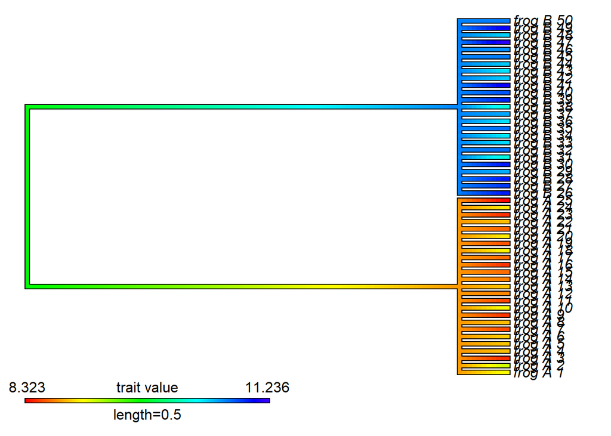

```r
par(mfrow=c(1,1))
contMap(tree = tree,x = tongue_length)
```

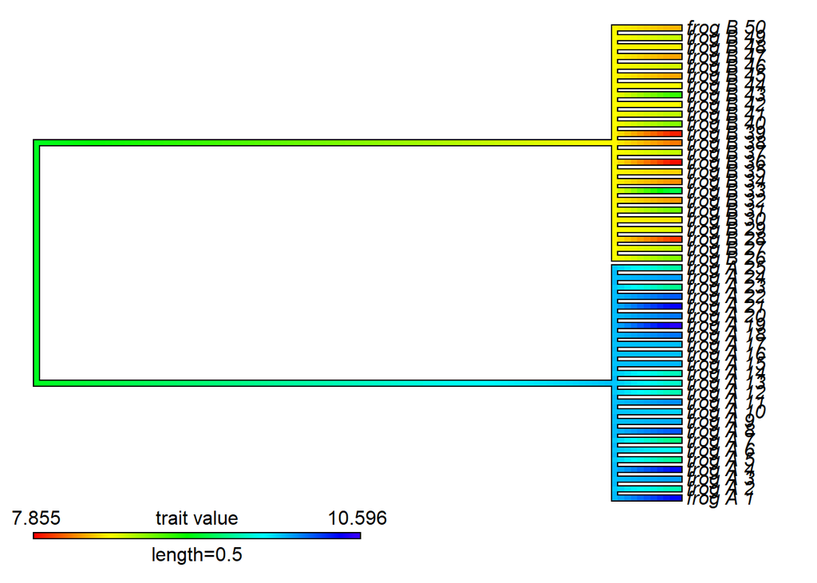

```r
contMap(tree = tree,x = hop_height)
```

Warning – the `contMap` function does weird things to the plot area. Run the function `dev.off()` when you’re done using `contMap` if you want to make other types of plots.

```r
# dev.off()
```

Let’s try generating this data few times and look at the different distributions of the trait values. Click the green button a few times below and see if the traits appear correlated (remember: the traits are actually independent, so any appearance of correlation is a relic of evolutionary history!)

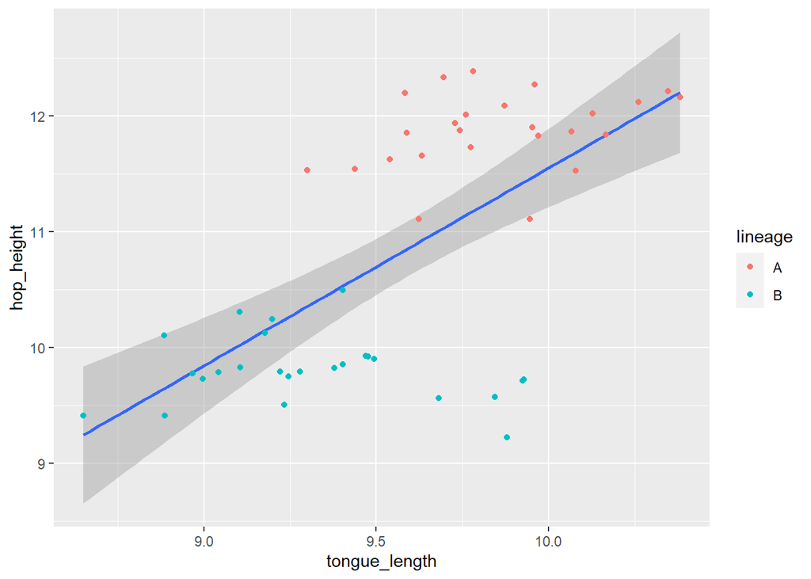

```r
tongue_length <- rTrait(n = 1,phy = tree) + 10
hop_height <- rTrait(n = 1,phy = tree) + 10

frog_dat <- data.frame(tongue_length = tongue_length,hop_height = hop_height,lineage = c(rep("A",25),rep("B",25)))
mod_frog <- lm(hop_height ~ tongue_length,data = frog_dat)

frog_dat %>%
  ggplot(mapping = aes(x = tongue_length,y = hop_height)) +
  stat_smooth(method = "lm") +
  geom_point(mapping = aes(color = lineage))
```

It turns out there are ways to account for these evolutionary relics. The classical approach is called phylogenetically independent contrasts (PICs) (Felsenstein 1985), which reconstructs the evolutionary history of bot trait values, and assesses whether or not the traits consistently evolved in a correlated manner, from anestral nodes to present day, *rather than* assessing the correlation on present day species.

I’ve include the code for PICs below. If we plot the phylogenetically independent contrasts (rather than the present-day species data), we can see the evolutionary relic disappears:

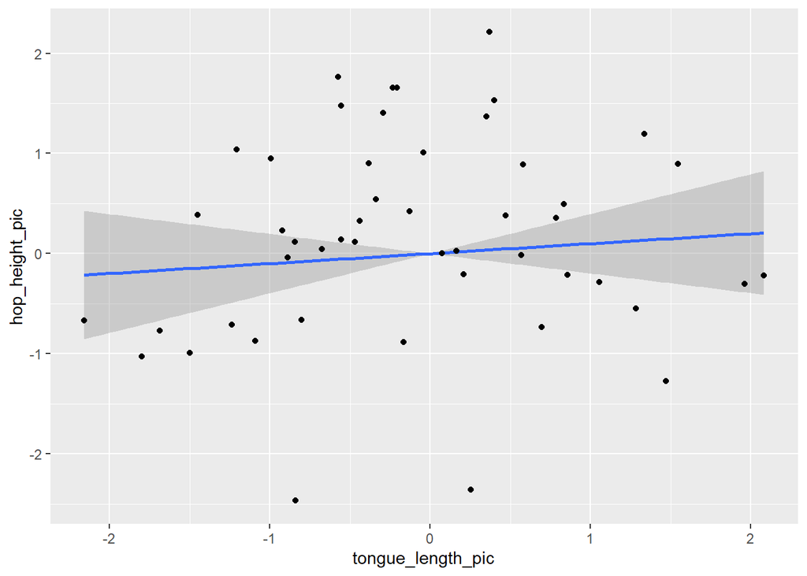

```r
ditree <- multi2di(tree,random = FALSE)
tongue_length_pic <- pic(tongue_length,ditree)
hop_height_pic <- pic(hop_height,ditree)

frog_dat_pics <- data.frame(tongue_length_pic = tongue_length_pic,hop_height_pic = hop_height_pic)
mod_frog_pics <- lm(hop_height_pic ~ tongue_length_pic,data = frog_dat)

frog_dat_pics %>%
  ggplot(mapping = aes(x = tongue_length_pic,y = hop_height_pic)) +
  stat_smooth(method = "lm",formula = y~x-1) +
  geom_point()
```

A newer (statistically equivalent) approach is now available, and it’s called phylogenetic regression (also known as phylogenetic generalized least squares, or PGLS). It’s advantageous because we don’t have to use contrasts – we can simply account for phylogeny when looking at species data:

```r
phylo_mod <- phylolm(hop_height ~ tongue_length,phy = tree,data = frog_dat)
summary(phylo_mod)
```

```
##
## Call:
## phylolm(formula = hop_height ~ tongue_length, data = frog_dat,
##     phy = tree)
##
##    AIC logLik
##  43.18 -18.59
##
## Raw residuals:
##      Min       1Q   Median       3Q      Max
## -1.64621 -1.00168 -0.04828  1.01697  1.52320
##
## Mean tip height: 1
## Parameter estimate(s) using ML:
## sigma2: 0.9915046
##
## Coefficients:
##               Estimate   StdErr t.value   p.value
## (Intercept)   9.886654 1.569696  6.2985 8.762e-08 ***
## tongue_length 0.099518 0.147458  0.6749     0.503
## ---
## Signif. codes:  0 '***' 0.001 '**' 0.01 '*' 0.05 '.' 0.1 ' ' 1
##
## R-squared: 0.0094    Adjusted R-squared: -0.01124
```

Let’s compare the false positive rate for regular regression vs phylogenetic regression:

```r
lm_p_values <- numeric(length = 1000)
phylo_p_values <- numeric(length = 1000)

for(i in 1:1000)
{
  tongue_length <- rTrait(n = 1,phy = tree) + 10
  hop_height <- rTrait(n = 1,phy = tree) + 10

  frog_dat <- data.frame(tongue_length = tongue_length,hop_height = hop_height,lineage = c(rep("A",25),rep("B",25)))
  mod_frog <- lm(hop_height ~ tongue_length,data = frog_dat)
  phylo_mod <- phylolm(hop_height ~ tongue_length,phy = tree,data = frog_dat)

  lm_p_values[i] <- summary(mod_frog)$coefficients[2,4]
  phylo_p_values[i] <- summary(phylo_mod)$coefficients[2,4]
}

sum(lm_p_values < .05) / length(lm_p_values) * 100
```

```
## [1] 75.5
```

```r
sum(phylo_p_values < .05) / length(phylo_p_values) * 100
```

```
## [1] 6.7
```

For non-phylogenetic regression, we see a falst positive about 75% of the time!! With phylogenetic regression, we only see a false positive about 5% of the time.

There are so many applications of phylogenetic comparative methods in addition to what we have covered here. We can also study the evolutionary history of discrete (categorical) traits:

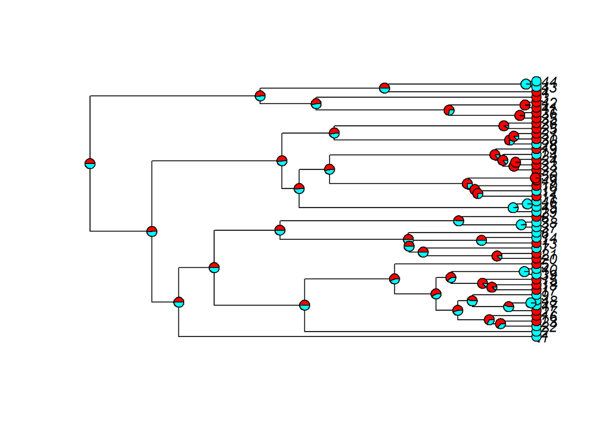

```r
tree <- pbtree(n = 50)
plot(tree)

# simulate binary trait
binary_trait <- rbinTrait(n = 1,phy = tree,beta=c(0), alpha=1)

# reconstruct evolutionary history
reconstruction <- ace(x = binary_trait,type = "discrete",phy = tree)

# plot evolutionary history
plot(tree)
tiplabels(pie = binary_trait,cex = 0.5)
nodelabels(pie = reconstruction$lik.anc[,2],cex = 0.5)
```

Feel free to reach out to me if you’re interested in learning more about phylogenetic comparative methods. It’s my favorite topic! As a shameless self-plug, here’s a link to my R package, Rphylopars: https://github.com/ericgoolsby/Rphylopars/wiki.